# Bikes_EDA_hypothesistesting

## 1. Problem Statement

A bike rental business provides the safest commute solution through a mobile app to enable shared, solo and sustainable commuting. They have contracted a consulting company to understand the factors on which the shared electric cycles depends on in the Indian market. They want to know which variables are significant in predicting the demand and how strongly those variables describe these demands. We will take a look at the data for more than 10,000 entries of electric cycle usage, and see if the weather, temperature, humidity, day being working or a holiday can affect the cycle demands.

```python
import numpy as np, seaborn as sns, pandas as pd, math, matplotlib.pyplot as plt, scipy.stats
from scipy.stats import chi2, chi2_contingency, ttest_ind, f_oneway
import statsmodels
from statsmodels.stats.weightstats import ztest
```

```python
bikes = pd.read_csv('/content/bike_sharing.csv?1642089089')
```

```python
bikes.shape # shape of dataset
```

```
(10886, 12)
```

```python
bikes.info()  # information about columns, their data types, count
```

```
<class 'pandas.core.frame.DataFrame'>
RangeIndex: 10886 entries, 0 to 10885
Data columns (total 12 columns):
 #   Column      Non-Null Count  Dtype
---  ------      --------------  -----
 0   datetime    10886 non-null  object
 1   season      10886 non-null  int64
 2   holiday     10886 non-null  int64
 3   workingday  10886 non-null  int64
 4   weather     10886 non-null  int64
 5   temp        10886 non-null  float64
 6   atemp       10886 non-null  float64
 7   humidity    10886 non-null  int64
 8   windspeed   10886 non-null  float64
 9   casual      10886 non-null  int64
 10  registered  10886 non-null  int64
 11  count       10886 non-null  int64
dtypes: float64(3), int64(8), object(1)
memory usage: 1020.7+ KB
```

There are 10886 rows, 12 columns. There are some numerical variables that can be converted to categorical columns by changing the numbers to categories such as in season, holiday, workingday, and weather.

```python
bikes.season.replace([1,2,3,4,],['spring','summer','fall','winter'],inplace=True)
```

```python
bikes.season.value_counts()
```

```
winter    2734
summer    2733
fall      2733
spring    2686
Name: season, dtype: int64
```

```python
bikes.holiday.replace([0,1],['no_holiday','holiday'],inplace=True) # converting numerical to categorical variable
```

```python
bikes.holiday.value_counts()
```

```
no_holiday    10575
holiday         311
Name: holiday, dtype: int64
```

There are only 311 holiday entries in the dataset, most entries are from non holiday days.

```python
bikes.workingday.replace([0,1],['not_working','working'],inplace=True) # converting numerical to categorical variablev
```

```python
bikes.workingday.value_counts()
```

```
working        7412
not_working    3474
Name: workingday, dtype: int64
```

There are almost double working day entries compared to weekend and holiday entries.

```python
bikes.weather.replace([1,2,3,4],['clear','misty','light_rain/snow','heavy_rain/snow'],inplace=True) # converting numerical to categorical variable
```

```python
bikes.weather.value_counts()
```

```
clear              7192
misty              2834
light_rain/snow     859
heavy_rain/snow       1
Name: weather, dtype: int64
```

Let's look at the numerical variables

## 2. Univariate analysis

```python
bikes.describe() # statistical summary of all numerical variables
```

|  | temp | atemp | humidity | windspeed | casual | registered | count |
| --- | --- | --- | --- | --- | --- | --- | --- |
| count | 10886.00000 | 10886.000000 | 10886.000000 | 10886.000000 | 10886.000000 | 10886.000000 | 10886.000000 |
| mean | 20.23086 | 23.655084 | 61.886460 | 12.799395 | 36.021955 | 155.552177 | 191.574132 |
| std | 7.79159 | 8.474601 | 19.245033 | 8.164537 | 49.960477 | 151.039033 | 181.144454 |
| min | 0.82000 | 0.760000 | 0.000000 | 0.000000 | 0.000000 | 0.000000 | 1.000000 |
| 25% | 13.94000 | 16.665000 | 47.000000 | 7.001500 | 4.000000 | 36.000000 | 42.000000 |
| 50% | 20.50000 | 24.240000 | 62.000000 | 12.998000 | 17.000000 | 118.000000 | 145.000000 |
| 75% | 26.24000 | 31.060000 | 77.000000 | 16.997900 | 49.000000 | 222.000000 | 284.000000 |
| max | 41.00000 | 45.455000 | 100.000000 | 56.996900 | 367.000000 | 886.000000 | 977.000000 |

Mean number of users who used a bike in an hour on a day is 191.

### Missing values and outlier detection

```python
bikes.isnull().sum()
```

```
datetime      0
season        0
holiday       0
workingday    0
weather       0
temp          0
atemp         0
humidity      0
windspeed     0
casual        0
registered    0
count         0
dtype: int64
```

There are no missing values.

Let us look at any outliers present in the numerical variables like temp, atemp, humidity, windspeed, casual, registered.

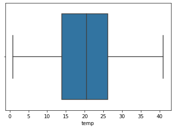

```python
sns.boxplot(bikes.temp) # looking at the spread of Purchase amount
```

There are no outliers in temperature variable.

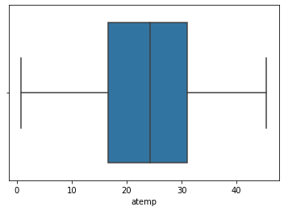

```python
sns.boxplot(bikes.atemp)
```

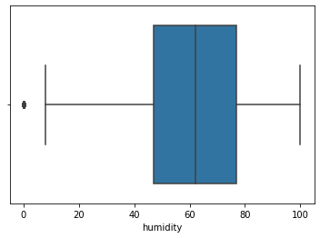

```python
sns.boxplot(bikes.humidity)
```

There is an outlier at 0 humidity, which is a reasonable number for a dry day so we would not discard it.

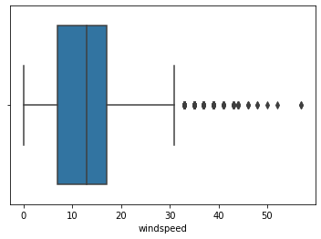

```python
sns.boxplot(bikes.windspeed)
```

Windspeed seems to have a right skewed distribution which lots of large outliers, but they seem like high winds days and not errors so we would not discard them.

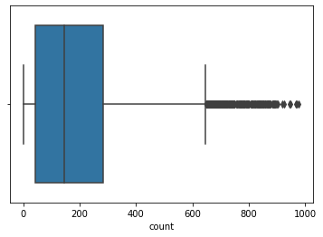

```python
sns.boxplot(bikes['count'])
```

```python
iqr = scipy.stats.iqr(bikes['count']) # inter quartile range
q3 = np.percentile(bikes['count'],75) # third quartile
bikes['count'][bikes['count'] > (q3 +iqr*1.5)] # outlier points
```

```
6611     712
6634     676
6635     734
6649     662
6658     782
        ...
10678    724
10702    688
10726    679
10846    662
10870    678
Name: count, Length: 300, dtype: int64
```

There are 300 outliers all closely situated, and don't seem like error in measurement. So we would keep them.

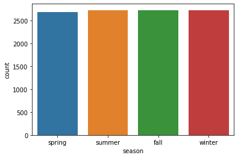

```python
sns.countplot(data=bikes, x = 'season') # all seasons have almost equal number of days
```

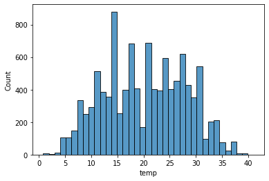

```python
sns.histplot(data=bikes, x='temp')
```

This looks quite normally distributed.

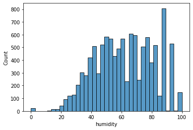

```python
sns.histplot(data=bikes, x='humidity')
```

Humidity looks slightly normal distribution but more higher humidity numbers are present.

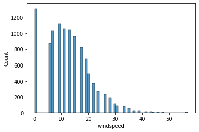

```python
sns.histplot(data=bikes, x='windspeed')
```

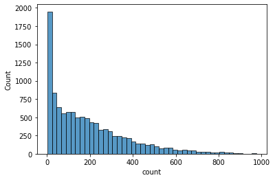

```python
sns.histplot(data=bikes, x='count') # histogram of number of users per hour is almost linearly decreasing with increasing frequency, apart from 0 users at a time
```

This looks slightly like an exponential distribution.

## 3. Bivariate analysis

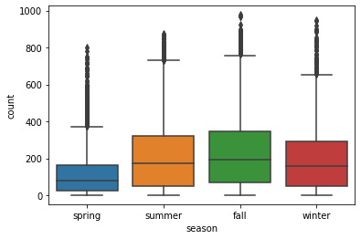

```python
sns.boxplot(data=bikes, x='season', y='count')
```

Mean number of users who used a bike in an hour on a day is 191.

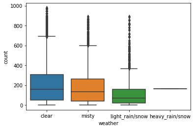

```python
sns.boxplot(data=bikes, x='weather', y='count')
```

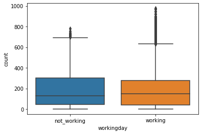

```python
sns.boxplot(data=bikes, y='count', x='workingday')
```

The median number of users per hour on a working day and non working day are similar. To check statistical significance we need to perform 2-sample T-tests as the population standard deviation is unknown.

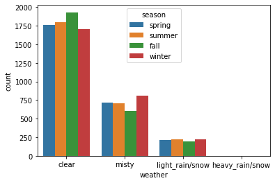

```python
sns.countplot(data=bikes, x='weather', hue='season')
```

The number of hours recorded in every season is similar for light rain/snow weather and heavy rain/snow weather. However, they are different for clear sky weather, misty weather. We can check the statistical significance using chi-square to check the proportions.

## 4. Hypothesis testing

### 2- Sample T-Test to check if Working Day has an effect on the number of electric cycles rented

Some of the assumptions of the T-test are met such as random sampling, adequate number of samples. But some assumptions are not met such as Normality, Equal Variance.

We would continue doing the analysis even if some assumptions fail.

T-test Ho: the means for counts of users for working day and non working day entries are equal.

Ha: they are unequal

```python
a = bikes[bikes['workingday']=='not_working']['count']
b = bikes[bikes['workingday']=='working']['count']
print(np.array(a).var(),np.array(b).var()) # variances are different for the two groups
ttest_ind(a,b)
```

```
30171.346098942427 34040.69710674686
```

```
Ttest_indResult(statistic=-1.2096277376026694, pvalue=0.22644804226361348)
```

T-test p-value 0.23 is larger than alpha=0.05. So we fail to reject the null hypothesis. Hence, similar to the visual analysis plots, working day has no statistically significant effect on the mean of number of cycles.

### ANOVA to check if No. of cycles rented is similar or different in different 1. weather 2. season

#### 1. Weather

Ho : mean number of cycles rented per hour in different weather is similar

Ha : mean number of cycles rented are different for different weather

```python
a= bikes[bikes['weather']=='clear']['count']
b = bikes[bikes['weather']=='misty']['count']
c = bikes[bikes['weather']=='light_rain/snow']['count']
d = bikes[bikes['weather']=='heavy_rain/snow']['count']
print(np.array(a).var(),np.array(b).var(),np.array(c).var(),np.array(d).var()) # variances for the 4 groups
f_oneway(a,b,c,d)
```

```
35323.8862270764 28337.246435435423 19182.418761290777 0.0
```

```
F_onewayResult(statistic=65.53024112793271, pvalue=5.482069475935669e-42)
```

We assume that the variance for different population groups is same in order to perform F-test ANOVA, even though they differ largely.

As the p-value (5.5e-42) is very low, we reject the null hypothesis with a 95% confidence level (alpha=0.05). We can say that the mean number of cycles differs for different weather days, they are not independent.

#### 2. Seasons

Ho : mean number of cycles rented per hour in different seasons is similar

Ha : mean number of cycles rented are different for different seasons

```python
a= bikes[bikes['season']=='spring']['count']
b = bikes[bikes['season']=='summer']['count']
c = bikes[bikes['season']=='fall']['count']
d = bikes[bikes['season']=='winter']['count']
print(np.array(a).var(),np.array(b).var(),np.array(c).var(),np.array(d).var()) # variances for the 4 groups
f_oneway(a,b,c,d)
```

```
15687.725805298038 36853.522249306465 38854.295089130974 31538.180550642726
```

```
F_onewayResult(statistic=236.94671081032106, pvalue=6.164843386499654e-149)
```

We assume that the variances being different doesn't affect the ANOVA F-test.

As the p-value is very low (6.2e-149), we reject the null hypothesis at 95% confidence level (alpha=0.05). We can say that the mean number of cycles differs for different seasons, they are not independent of each other.

### Chi-square test to check if Weather is dependent on the season

```python
crosstable = pd.crosstab(index=bikes['weather'],columns=bikes['season'])
crosstable
```

| season weather | fall | spring | summer | winter |
| --- | --- | --- | --- | --- |
| clear | 1930 | 1759 | 1801 | 1702 |
| heavy_rain/snow | 0 | 1 | 0 | 0 |
| light_rain/snow | 199 | 211 | 224 | 225 |
| misty | 604 | 715 | 708 | 807 |

There are counts/frequencies for different weather in different seasons. They can be assumed to be independent of each other. So, we create a null hypothesis for chi-square test.

Ho: the proportion of different weather days is equal for all seasons.

Ha: the proportions are not equal, weather days are dependent on seasons.

```python
chi2_contingency(crosstable)
```

```
(49.15865559689363,
 1.5499250736864862e-07,
 9,
 array([[1.80559765e+03, 1.77454639e+03, 1.80559765e+03, 1.80625831e+03],
        [2.51056403e-01, 2.46738931e-01, 2.51056403e-01, 2.51148264e-01],
        [2.15657450e+02, 2.11948742e+02, 2.15657450e+02, 2.15736359e+02],
        [7.11493845e+02, 6.99258130e+02, 7.11493845e+02, 7.11754180e+02]]))
```

As per the visual analysis, the number of hours recorded in every season is similar for light rain/snow weather and heavy rain/snow weather. However, they are different for clear sky weather, misty weather. The statistical test confirms this as p-value is very low (1.5e-7) so null hypothesis is rejected.

## 5. Inferences

Mean number of users who used a bike in an hour on a day is 191.

T-test p-value 0.23 is larger than alpha=0.05. So we fail to reject the null hypothesis. Hence, similar to the visual analysis plots, **working day has no statistically significant effect on the mean of number of cycles**.

As the ANOVA p-value is very low (6.2e-149), we reject the null hypothesis at 95% confidence level (alpha=0.05). We can say that the mean **number of cycles differs for different seasons**.

As per the visual analysis, the number of hours recorded in every season is similar for light rain/snow weather and heavy rain/snow weather. However, they are different for clear sky weather, misty weather. The statistical chi-square test confirms this as p-value is very low (1.5e-7) so null hypothesis is rejected. **Weather and seasons are not independent.**

## 6. Recommendations

Weather and seasons are significant predictors for the demand for electric cycles as per this dataset

Clear sky and misty days have more demand so the fare can be increased for those days, and fare for light and heavy rain/snow days can be decreased.

Spring days can have reduced fares to increase number of users.